# **Problem Statement**

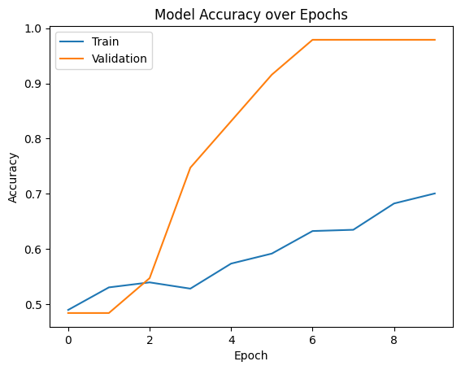

```python
plt.plot(history_2.history['accuracy'])
plt.plot(history_2.history['val_accuracy'])
plt.title('Model Accuracy over Epochs')
plt.ylabel('Accuracy')
plt.xlabel('Epoch')
plt.legend(['Train', 'Validation'], loc='upper left')
plt.show()
```

** OBSERVATION:**

```
Train performance metrics:
14/14 ━━━━━━━━━━━━━━━━━━━━ 4s 211ms/step
```

|  | Accuracy | Recall | Precision | F1 Score |
| --- | --- | --- | --- | --- |
| 0 | 0.995465 | 0.995465 | 0.995505 | 0.995464 |

```
14/14 ━━━━━━━━━━━━━━━━━━━━ 2s 143ms/step
```

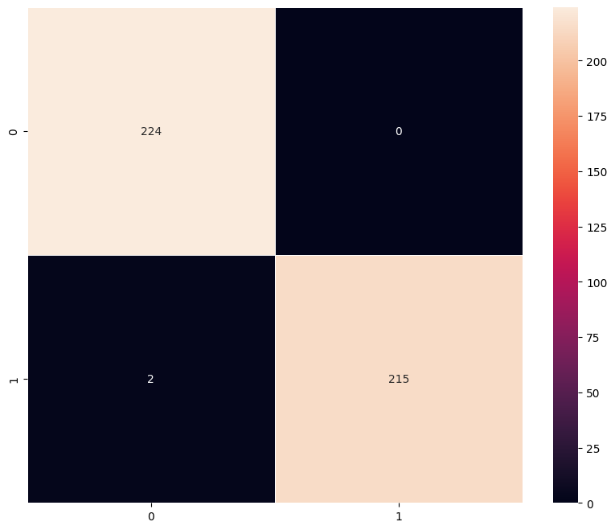

```
Validation performance metrics:
3/3 ━━━━━━━━━━━━━━━━━━━━ 1s 359ms/step
```

|  | Accuracy | Recall | Precision | F1 Score |
| --- | --- | --- | --- | --- |
| 0 | 0.978947 | 0.978947 | 0.978947 | 0.978947 |

```
============================================================
CONFUSION MATRIX
============================================================

3/3 ━━━━━━━━━━━━━━━━━━━━ 0s 149ms/step
```

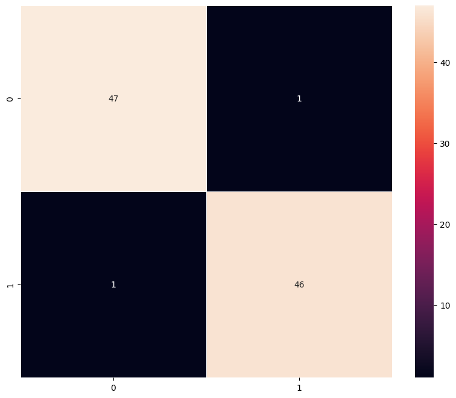

```python
# Evaluate on Train Set
print("Train performance metrics:")
cnn_model_2_train_perf = model_performance_classification(cnn_model_2, X_train_vgg, pd.Series(y_train))
display(cnn_model_2_train_perf)

plot_confusion_matrix(cnn_model_2, X_train_vgg, pd.Series(y_train))

# Evaluate on Validation Set
print("Validation performance metrics:")
cnn_model_2_val_perf = model_performance_classification(cnn_model_2, X_val_vgg, pd.Series(y_val))
display(cnn_model_2_val_perf)

print("\n" + "=" * 60)
print("CONFUSION MATRIX")
print("=" * 60 + "\n")  # print separator line

plot_confusion_matrix(cnn_model_2, X_val_vgg, pd.Series(y_val))

# Hold off on Test Set — uncomment only when ready to evaluate final model
# print("Test performance metrics:")
# cnn_model_2_test_perf = model_performance_classification(cnn_model_2, X_test_vgg, pd.Series(y_test))
# display(cnn_model_2_test_perf)

# print("\n" + "=" * 60)
# print("CONFUSION MATRIX")
# print("=" * 60 + "\n")

# plot_confusion_matrix(cnn_model_2, X_test_vgg, pd.Series(y_test))
```

```
1/1 ━━━━━━━━━━━━━━━━━━━━ 1s 509ms/step
Predicted Label: 1
True Label: 1
```

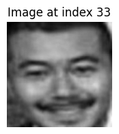

```
1/1 ━━━━━━━━━━━━━━━━━━━━ 0s 42ms/step
Predicted Label: 0
True Label: 0
```

```python
# For index 12
index = 12
plt.figure(figsize=(2, 2))
plt.imshow(X_val[index].reshape(X_val.shape[1], X_val.shape[2]), cmap='gray')  # grayscale view
plt.title(f"Image at index {index}")
plt.axis('off')
plt.show()

# Predict using the RGB-converted version
prediction = cnn_model_2.predict(X_val_vgg[index].reshape(1, X_val.shape[1], X_val.shape[2], 3))
predicted_label = 1 if prediction[0][0] > 0.5 else 0
print('Predicted Label:', predicted_label)
print('True Label:', y_val[index])

# For index 33
index = 33
plt.figure(figsize=(2, 2))
plt.imshow(X_val[index].reshape(X_val.shape[1], X_val.shape[2]), cmap='gray')  # grayscale view
plt.title(f"Image at index {index}")
plt.axis('off')
plt.show()

prediction = cnn_model_2.predict(X_val_vgg[index].reshape(1, X_val.shape[1], X_val.shape[2], 3))
predicted_label = 1 if prediction[0][0] > 0.5 else 0
print('Predicted Label:', predicted_label)
print('True Label:', y_val[index])
```

```
Enter a number: 23
You are trying to figure out a particular image number: 23
```

[figure not shown]

```
1/1 ━━━━━━━━━━━━━━━━━━━━ 0s 43ms/step
Predicted Label: Person is wearing the helmet
True Label: Person is wearing the helmet
```

```python
index = int(input("Enter a number: "))
print("You are trying to figure out a particular image number:", index)


plt.figure(figsize=(2, 2))
plt.imshow(X_val[index].reshape(X_val.shape[1], X_val.shape[2]), cmap='gray')  # grayscale view
plt.title(f"Image at index {index}")
plt.axis('off')
plt.show()

# Predict using the RGB-converted version
prediction = cnn_model_2.predict(X_val_vgg[index].reshape(1, X_val.shape[1], X_val.shape[2], 3))
predicted_label = 1 if prediction[0][0] > 0.5 else 0

if predicted_label == 1:
    print('Predicted Label: Person is wearing the helmet')
else:
    print('Predicted Label: Person is not wearing a helmet')

if y_val[index] == 1:
    print('True Label: Person is wearing the helmet')
else:
    print('True Label: Person is not wearing a helmet')
```

** Observation **

- From the above prediction, we can see that the model predicted both images correctly when the image is hardcoded.
- From above prediction tried to get data from user and predict and it predicted properly

## Model 3: (VGG-16 (Base + FFNN))

```python
# Convert grayscale to RGB-like format for VGG (e.g., (128, 128, 1) → (128, 128, 3))
X_train_vgg = np.repeat(X_train, 3, axis=-1)
X_val_vgg = np.repeat(X_val, 3, axis=-1)
X_test_vgg = np.repeat(X_test, 3, axis=-1)
```

** Load VGG16 without top classifier **

```python
# Load base VGG16 model without top layer
vgg_base = VGG16(weights='imagenet', include_top=False, input_shape=X_train_vgg.shape[1:])

# Freeze all layers first
for layer in vgg_base.layers:
    layer.trainable = False

# Unfreeze the last 4 layers
# for layer in vgg_base.layers[-4:]:
#   layer.trainable = True
```

** Add a deepr FFNN Head **

```python
# Add a Deeper FFNN Head
x = vgg_base.output
x = Flatten()(x)
x = Dense(256, activation='relu')(x)
x = Dropout(0.7)(x)
x = Dense(128, activation='relu')(x)
x = Dropout(0.8)(x)
output = Dense(1, activation='sigmoid')(x)
```

** Compile the Model **

```python
# Define the final model
cnn_model_3 = Model(inputs=vgg_base.input, outputs=output)

cnn_model_3.compile(
    optimizer=Adam(learning_rate=0.00001),  # small LR is safer with pre-trained weights
    loss='binary_crossentropy',
    metrics=['accuracy']
)

cnn_model_3.summary()
```

```
Model: "functional_3"
```

```
┏━━━━━━━━━━━━━━━━━━━━━━━━━━━━━━━━━┳━━━━━━━━━━━━━━━━━━━━━━━━┳━━━━━━━━━━━━━━━┓
┃ Layer (type)                    ┃ Output Shape           ┃       Param # ┃
┡━━━━━━━━━━━━━━━━━━━━━━━━━━━━━━━━━╇━━━━━━━━━━━━━━━━━━━━━━━━╇━━━━━━━━━━━━━━━┩
│ input_layer_3 (InputLayer)      │ (None, 200, 200, 3)    │             0 │
├─────────────────────────────────┼────────────────────────┼───────────────┤
│ block1_conv1 (Conv2D)           │ (None, 200, 200, 64)   │         1,792 │
├─────────────────────────────────┼────────────────────────┼───────────────┤
│ block1_conv2 (Conv2D)           │ (None, 200, 200, 64)   │        36,928 │
├─────────────────────────────────┼────────────────────────┼───────────────┤
│ block1_pool (MaxPooling2D)      │ (None, 100, 100, 64)   │             0 │
├─────────────────────────────────┼────────────────────────┼───────────────┤
│ block2_conv1 (Conv2D)           │ (None, 100, 100, 128)  │        73,856 │
├─────────────────────────────────┼────────────────────────┼───────────────┤
│ block2_conv2 (Conv2D)           │ (None, 100, 100, 128)  │       147,584 │
├─────────────────────────────────┼────────────────────────┼───────────────┤
│ block2_pool (MaxPooling2D)      │ (None, 50, 50, 128)    │             0 │
├─────────────────────────────────┼────────────────────────┼───────────────┤
│ block3_conv1 (Conv2D)           │ (None, 50, 50, 256)    │       295,168 │
├─────────────────────────────────┼────────────────────────┼───────────────┤
│ block3_conv2 (Conv2D)           │ (None, 50, 50, 256)    │       590,080 │
├─────────────────────────────────┼────────────────────────┼───────────────┤
│ block3_conv3 (Conv2D)           │ (None, 50, 50, 256)    │       590,080 │
├─────────────────────────────────┼────────────────────────┼───────────────┤
│ block3_pool (MaxPooling2D)      │ (None, 25, 25, 256)    │             0 │
├─────────────────────────────────┼────────────────────────┼───────────────┤
│ block4_conv1 (Conv2D)           │ (None, 25, 25, 512)    │     1,180,160 │
├─────────────────────────────────┼────────────────────────┼───────────────┤
│ block4_conv2 (Conv2D)           │ (None, 25, 25, 512)    │     2,359,808 │
├─────────────────────────────────┼────────────────────────┼───────────────┤
│ block4_conv3 (Conv2D)           │ (None, 25, 25, 512)    │     2,359,808 │
├─────────────────────────────────┼────────────────────────┼───────────────┤
│ block4_pool (MaxPooling2D)      │ (None, 12, 12, 512)    │             0 │
├─────────────────────────────────┼────────────────────────┼───────────────┤
│ block5_conv1 (Conv2D)           │ (None, 12, 12, 512)    │     2,359,808 │
├─────────────────────────────────┼────────────────────────┼───────────────┤
│ block5_conv2 (Conv2D)           │ (None, 12, 12, 512)    │     2,359,808 │
├─────────────────────────────────┼────────────────────────┼───────────────┤
│ block5_conv3 (Conv2D)           │ (None, 12, 12, 512)    │     2,359,808 │
├─────────────────────────────────┼────────────────────────┼───────────────┤
│ block5_pool (MaxPooling2D)      │ (None, 6, 6, 512)      │             0 │
├─────────────────────────────────┼────────────────────────┼───────────────┤
│ flatten_3 (Flatten)             │ (None, 18432)          │             0 │
├─────────────────────────────────┼────────────────────────┼───────────────┤
│ dense_7 (Dense)                 │ (None, 256)            │     4,718,848 │
├─────────────────────────────────┼────────────────────────┼───────────────┤
│ dropout_4 (Dropout)             │ (None, 256)            │             0 │
├─────────────────────────────────┼────────────────────────┼───────────────┤
│ dense_8 (Dense)                 │ (None, 128)            │        32,896 │
├─────────────────────────────────┼────────────────────────┼───────────────┤
│ dropout_5 (Dropout)             │ (None, 128)            │             0 │
├─────────────────────────────────┼────────────────────────┼───────────────┤
│ dense_9 (Dense)                 │ (None, 1)              │           129 │
└─────────────────────────────────┴────────────────────────┴───────────────┘
```

```
 Total params: 19,466,561 (74.26 MB)
```

```
 Trainable params: 4,751,873 (18.13 MB)
```

```
 Non-trainable params: 14,714,688 (56.13 MB)
```

```python
history_3 = cnn_model_3.fit(
    X_train_vgg, y_train,
    validation_data=(X_val_vgg, y_val),
    epochs=10,
    batch_size=32,
    verbose=2
)
```

```
14/14 - 10s - 681ms/step - accuracy: 0.4898 - loss: 1.2692 - val_accuracy: 0.4947 - val_loss: 0.6424
14/14 - 3s - 197ms/step - accuracy: 0.5737 - loss: 0.9580 - val_accuracy: 0.7684 - val_loss: 0.5714
14/14 - 3s - 189ms/step - accuracy: 0.4943 - loss: 1.0132 - val_accuracy: 0.9789 - val_loss: 0.5123
14/14 - 3s - 186ms/step - accuracy: 0.5737 - loss: 0.7951 - val_accuracy: 0.9895 - val_loss: 0.4672
14/14 - 3s - 189ms/step - accuracy: 0.6145 - loss: 0.7962 - val_accuracy: 0.9895 - val_loss: 0.4351
14/14 - 3s - 189ms/step - accuracy: 0.6871 - loss: 0.6086 - val_accuracy: 0.9895 - val_loss: 0.4068
14/14 - 3s - 194ms/step - accuracy: 0.6939 - loss: 0.6440 - val_accuracy: 0.9895 - val_loss: 0.3757
14/14 - 3s - 194ms/step - accuracy: 0.7324 - loss: 0.5238 - val_accuracy: 0.9895 - val_loss: 0.3484
14/14 - 3s - 193ms/step - accuracy: 0.7120 - loss: 0.5414 - val_accuracy: 0.9895 - val_loss: 0.3236
14/14 - 3s - 194ms/step - accuracy: 0.7415 - loss: 0.5022 - val_accuracy: 0.9895 - val_loss: 0.2997
```

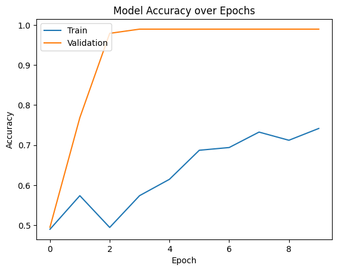

```python
plt.plot(history_3.history['accuracy'])
plt.plot(history_3.history['val_accuracy'])
plt.title('Model Accuracy over Epochs')
plt.ylabel('Accuracy')
plt.xlabel('Epoch')
plt.legend(['Train', 'Validation'], loc='upper left')
plt.show()
```

** OBSERVATION: **

```
Train performance metrics:
14/14 ━━━━━━━━━━━━━━━━━━━━ 5s 256ms/step
```

|  | Accuracy | Recall | Precision | F1 Score |
| --- | --- | --- | --- | --- |
| 0 | 1.0 | 1.0 | 1.0 | 1.0 |

```
14/14 ━━━━━━━━━━━━━━━━━━━━ 2s 148ms/step
```

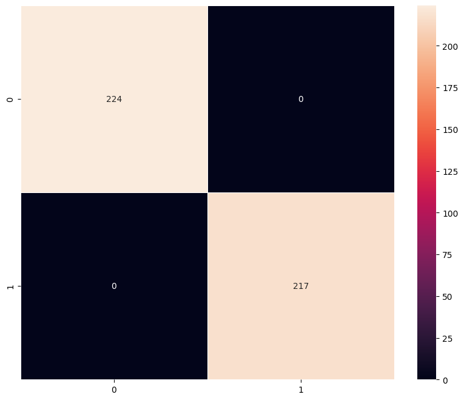

```
Validation performance metrics:
3/3 ━━━━━━━━━━━━━━━━━━━━ 1s 385ms/step
```

|  | Accuracy | Recall | Precision | F1 Score |
| --- | --- | --- | --- | --- |
| 0 | 0.989474 | 0.989474 | 0.989693 | 0.989474 |

```
============================================================
3/3 ━━━━━━━━━━━━━━━━━━━━ 1s 161ms/step
```

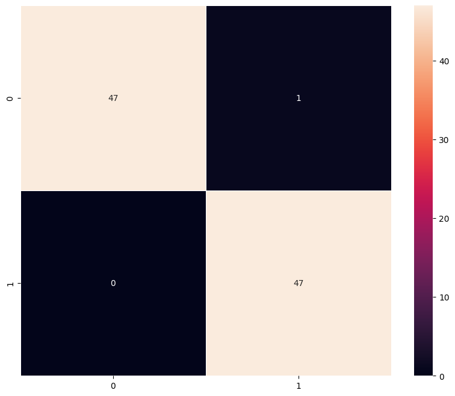

```python
print("Train performance metrics:")
cnn_model_3_train_perf = model_performance_classification(cnn_model_3, X_train_vgg, pd.Series(y_train))
display(cnn_model_3_train_perf)

plot_confusion_matrix(cnn_model_3, X_train_vgg, pd.Series(y_train))

print("\nValidation performance metrics:")
cnn_model_3_val_perf = model_performance_classification(cnn_model_3, X_val_vgg, pd.Series(y_val))
display(cnn_model_3_val_perf)

print("\n" + "="*60)
plot_confusion_matrix(cnn_model_3, X_val_vgg, pd.Series(y_val))
```

** Print class distributions to ensure my data is still balanced due to high scores. **

```python
print("Train:", np.bincount(y_train))
print("Val:", np.bincount(y_val))
print("Test:", np.bincount(y_test))
```

```
Train: [224 217]
Val: [48 47]
Test: [48 47]
```

#### Visualizing the predictions

```
1/1 ━━━━━━━━━━━━━━━━━━━━ 1s 532ms/step
Predicted Label: 1
True Label: 1
```

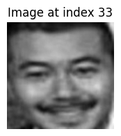

```
1/1 ━━━━━━━━━━━━━━━━━━━━ 0s 43ms/step
Predicted Label: 0
True Label: 0
```

```python
# For index 12
index = 12
plt.figure(figsize=(2, 2))
plt.imshow(X_val[index].reshape(X_val.shape[1], X_val.shape[2]), cmap='gray')  # grayscale view
plt.title(f"Image at index {index}")
plt.axis('off')
plt.show()

# Predict using the RGB-converted version
prediction = cnn_model_3.predict(X_val_vgg[index].reshape(1, X_val.shape[1], X_val.shape[2], 3))
predicted_label = 1 if prediction[0][0] > 0.5 else 0
print('Predicted Label:', predicted_label)
print('True Label:', y_val[index])

# For index 33
index = 33
plt.figure(figsize=(2, 2))
plt.imshow(X_val[index].reshape(X_val.shape[1], X_val.shape[2]), cmap='gray')  # grayscale view
plt.title(f"Image at index {index}")
plt.axis('off')
plt.show()

prediction = cnn_model_3.predict(X_val_vgg[index].reshape(1, X_val.shape[1], X_val.shape[2], 3))
predicted_label = 1 if prediction[0][0] > 0.5 else 0
print('Predicted Label:', predicted_label)
print('True Label:', y_val[index])
```

** OBSERVATION: **

- From the above prediction, we can see that the model predicted both images correctly.

## Model 4: (VGG-16 (Base + FFNN + Data Augmentation)

- In most of the real-world case studies, it is challenging to acquire a large number of images and then train CNNs.
- To overcome this problem, one approach we might consider is **Data Augmentation**.
- CNNs have the property of **translational invariance**, which means they can recognise an object even if its appearance shifts translationally in some way. - Taking this attribute into account, we can augment the images using the techniques listed below
  - Horizontal Flip (should be set to True/False)
  - Vertical Flip (should be set to True/False)
  - Height Shift (should be between 0 and 1)
  - Width Shift (should be between 0 and 1)
  - Rotation (should be between 0 and 180)
  - Shear (should be between 0 and 1)
  - Zoom (should be between 0 and 1) etc.

Remember, **data augmentation should not be used in the validation/test data set**.

```python
# Convert grayscale to RGB-like format for VGG (e.g., (128, 128, 1) → (128, 128, 3))
X_train_vgg = np.repeat(X_train, 3, axis=-1)
X_val_vgg = np.repeat(X_val, 3, axis=-1)
X_test_vgg = np.repeat(X_test, 3, axis=-1)
```

** Define Image DataGenerator for Augmentation **

```python
# Data augmentation only applied to training data
train_datagen = ImageDataGenerator(
    rotation_range=15,
    width_shift_range=0.1,
    height_shift_range=0.1,
    zoom_range=0.1,
    horizontal_flip=True,
    fill_mode='nearest'
)

# Validation/Test generators (no augmentation)
val_datagen = ImageDataGenerator()

# Flow from arrays
train_generator = train_datagen.flow(X_train_vgg, y_train, batch_size=32)
val_generator = val_datagen.flow(X_val_vgg, y_val, batch_size=32)
```

**Load VGG16 without the top classifier (reuse from cnn_model_3)**

```python
vgg_base = VGG16(weights='imagenet', include_top=False, input_shape=X_train_vgg.shape[1:])
for layer in vgg_base.layers:
    layer.trainable = False

x = vgg_base.output
x = Flatten()(x)
x = Dense(256, activation='relu')(x)
x = Dropout(0.7)(x)
x = Dense(128, activation='relu')(x)
x = Dropout(0.8)(x)
output = Dense(1, activation='sigmoid')(x)

cnn_model_4 = Model(inputs=vgg_base.input, outputs=output)
```

** Compile the model **

```python
# Define the final model
cnn_model_4 = Model(inputs=vgg_base.input, outputs=output)

cnn_model_4.compile(
    optimizer=Adam(learning_rate=0.000001),  # small LR is safer with pre-trained weights
    loss='binary_crossentropy',
    metrics=['accuracy']
)

cnn_model_4.summary()
```

```
Model: "functional_5"
```

```
┏━━━━━━━━━━━━━━━━━━━━━━━━━━━━━━━━━┳━━━━━━━━━━━━━━━━━━━━━━━━┳━━━━━━━━━━━━━━━┓
┃ Layer (type)                    ┃ Output Shape           ┃       Param # ┃
┡━━━━━━━━━━━━━━━━━━━━━━━━━━━━━━━━━╇━━━━━━━━━━━━━━━━━━━━━━━━╇━━━━━━━━━━━━━━━┩
│ input_layer_4 (InputLayer)      │ (None, 200, 200, 3)    │             0 │
├─────────────────────────────────┼────────────────────────┼───────────────┤
│ block1_conv1 (Conv2D)           │ (None, 200, 200, 64)   │         1,792 │
├─────────────────────────────────┼────────────────────────┼───────────────┤
│ block1_conv2 (Conv2D)           │ (None, 200, 200, 64)   │        36,928 │
├─────────────────────────────────┼────────────────────────┼───────────────┤
│ block1_pool (MaxPooling2D)      │ (None, 100, 100, 64)   │             0 │
├─────────────────────────────────┼────────────────────────┼───────────────┤
│ block2_conv1 (Conv2D)           │ (None, 100, 100, 128)  │        73,856 │
├─────────────────────────────────┼────────────────────────┼───────────────┤
│ block2_conv2 (Conv2D)           │ (None, 100, 100, 128)  │       147,584 │
├─────────────────────────────────┼────────────────────────┼───────────────┤
│ block2_pool (MaxPooling2D)      │ (None, 50, 50, 128)    │             0 │
├─────────────────────────────────┼────────────────────────┼───────────────┤
│ block3_conv1 (Conv2D)           │ (None, 50, 50, 256)    │       295,168 │
├─────────────────────────────────┼────────────────────────┼───────────────┤
│ block3_conv2 (Conv2D)           │ (None, 50, 50, 256)    │       590,080 │
├─────────────────────────────────┼────────────────────────┼───────────────┤
│ block3_conv3 (Conv2D)           │ (None, 50, 50, 256)    │       590,080 │
├─────────────────────────────────┼────────────────────────┼───────────────┤
│ block3_pool (MaxPooling2D)      │ (None, 25, 25, 256)    │             0 │
├─────────────────────────────────┼────────────────────────┼───────────────┤
│ block4_conv1 (Conv2D)           │ (None, 25, 25, 512)    │     1,180,160 │
├─────────────────────────────────┼────────────────────────┼───────────────┤
│ block4_conv2 (Conv2D)           │ (None, 25, 25, 512)    │     2,359,808 │
├─────────────────────────────────┼────────────────────────┼───────────────┤
│ block4_conv3 (Conv2D)           │ (None, 25, 25, 512)    │     2,359,808 │
├─────────────────────────────────┼────────────────────────┼───────────────┤
│ block4_pool (MaxPooling2D)      │ (None, 12, 12, 512)    │             0 │
├─────────────────────────────────┼────────────────────────┼───────────────┤
│ block5_conv1 (Conv2D)           │ (None, 12, 12, 512)    │     2,359,808 │
├─────────────────────────────────┼────────────────────────┼───────────────┤
│ block5_conv2 (Conv2D)           │ (None, 12, 12, 512)    │     2,359,808 │
├─────────────────────────────────┼────────────────────────┼───────────────┤
│ block5_conv3 (Conv2D)           │ (None, 12, 12, 512)    │     2,359,808 │
├─────────────────────────────────┼────────────────────────┼───────────────┤
│ block5_pool (MaxPooling2D)      │ (None, 6, 6, 512)      │             0 │
├─────────────────────────────────┼────────────────────────┼───────────────┤
│ flatten_4 (Flatten)             │ (None, 18432)          │             0 │
├─────────────────────────────────┼────────────────────────┼───────────────┤
│ dense_10 (Dense)                │ (None, 256)            │     4,718,848 │
├─────────────────────────────────┼────────────────────────┼───────────────┤
│ dropout_6 (Dropout)             │ (None, 256)            │             0 │
├─────────────────────────────────┼────────────────────────┼───────────────┤
│ dense_11 (Dense)                │ (None, 128)            │        32,896 │
├─────────────────────────────────┼────────────────────────┼───────────────┤
│ dropout_7 (Dropout)             │ (None, 128)            │             0 │
├─────────────────────────────────┼────────────────────────┼───────────────┤
│ dense_12 (Dense)                │ (None, 1)              │           129 │
└─────────────────────────────────┴────────────────────────┴───────────────┘
```

```
 Total params: 19,466,561 (74.26 MB)
```

```
 Trainable params: 4,751,873 (18.13 MB)
```

```
 Non-trainable params: 14,714,688 (56.13 MB)
```

** Train the model**

```python
history_4 = cnn_model_4.fit(
    train_generator,
    validation_data=val_generator,
    epochs=10,
    verbose=2
)
```

```
14/14 - 12s - 859ms/step - accuracy: 0.5193 - loss: 1.1466 - val_accuracy: 0.4737 - val_loss: 0.6995
14/14 - 5s - 342ms/step - accuracy: 0.4603 - loss: 1.1595 - val_accuracy: 0.5263 - val_loss: 0.6917
14/14 - 6s - 410ms/step - accuracy: 0.5238 - loss: 1.1281 - val_accuracy: 0.5684 - val_loss: 0.6843
14/14 - 5s - 338ms/step - accuracy: 0.5011 - loss: 1.0889 - val_accuracy: 0.6105 - val_loss: 0.6774
14/14 - 6s - 408ms/step - accuracy: 0.5601 - loss: 1.0059 - val_accuracy: 0.6632 - val_loss: 0.6701
14/14 - 5s - 333ms/step - accuracy: 0.5306 - loss: 0.9857 - val_accuracy: 0.6842 - val_loss: 0.6628
14/14 - 5s - 336ms/step - accuracy: 0.5193 - loss: 1.0455 - val_accuracy: 0.7158 - val_loss: 0.6553
14/14 - 6s - 409ms/step - accuracy: 0.5510 - loss: 1.0005 - val_accuracy: 0.7158 - val_loss: 0.6484
14/14 - 5s - 340ms/step - accuracy: 0.5510 - loss: 0.9832 - val_accuracy: 0.7263 - val_loss: 0.6415
14/14 - 5s - 372ms/step - accuracy: 0.5510 - loss: 0.9740 - val_accuracy: 0.7368 - val_loss: 0.6350
```

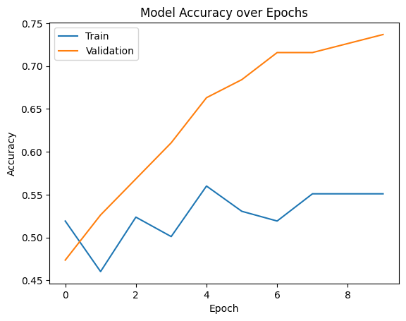

```python
plt.plot(history_4.history['accuracy'])
plt.plot(history_4.history['val_accuracy'])
plt.title('Model Accuracy over Epochs')
plt.ylabel('Accuracy')
plt.xlabel('Epoch')
plt.legend(['Train', 'Validation'], loc='upper left')
plt.show()
```

**Evaluate on Train & Validation Only (NOT test yet!)**

```
14/14 ━━━━━━━━━━━━━━━━━━━━ 4s 220ms/step
3/3 ━━━━━━━━━━━━━━━━━━━━ 1s 375ms/step
Training performance:
              precision    recall  f1-score   support

           0       0.80      0.92      0.86       224
           1       0.91      0.76      0.83       217

    accuracy                           0.84       441
   macro avg       0.85      0.84      0.84       441
weighted avg       0.85      0.84      0.84       441


Validation performance:
              precision    recall  f1-score   support

           0       0.69      0.85      0.77        48
           1       0.81      0.62      0.70        47

    accuracy                           0.74        95
   macro avg       0.75      0.74      0.73        95
weighted avg       0.75      0.74      0.73        95


Validation Confusion Matrix:
3/3 ━━━━━━━━━━━━━━━━━━━━ 0s 151ms/step
```

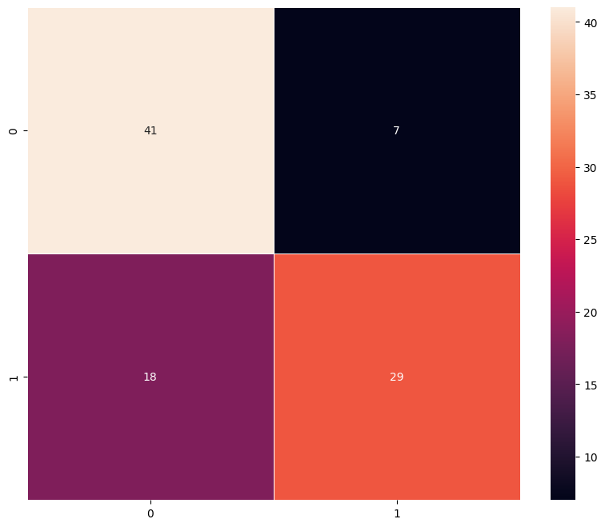

```python
# Predict on training and validation sets manually
train_preds = cnn_model_4.predict(X_train_vgg)
val_preds = cnn_model_4.predict(X_val_vgg)

# Convert probabilities to binary predictions
train_preds_bin = (train_preds > 0.5).astype(int)
val_preds_bin = (val_preds > 0.5).astype(int)

# Evaluate using  utility functions
print("Training performance:")
print(classification_report(y_train, train_preds_bin))

print("\nValidation performance:")
print(classification_report(y_val, val_preds_bin))

print("\nValidation Confusion Matrix:")
plot_confusion_matrix(cnn_model_4, X_val_vgg, pd.Series(y_val))
```

** Observations:** False Negatives (18): the model often fails to recognize actual helmet wearers False Positives (7): model occasionally predicts “helmet” when none is worn (but very few) This suggests the model is conservative, leaning toward classifying images as “no helmet” — which might be safer in a workplace compliance context (better to flag a worker than miss one not wearing PPE).

** Print the class distribution**

```python
print("Train:", np.bincount(y_train))
print("Val:", np.bincount(y_val))
print("Test:", np.bincount(y_test))
```

```
Train: [224 217]
Val: [48 47]
Test: [48 47]
```

#### Visualizing the predictions

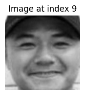

```
1/1 ━━━━━━━━━━━━━━━━━━━━ 1s 561ms/step
Predicted Label: 0
True Label: 0
```

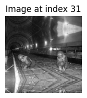

```
1/1 ━━━━━━━━━━━━━━━━━━━━ 0s 41ms/step
Predicted Label: 0
True Label: 1
```

```python
# For index 12
index = 9
plt.figure(figsize=(2, 2))
plt.imshow(X_val[index].reshape(X_val.shape[1], X_val.shape[2]), cmap='gray')  # grayscale view
plt.title(f"Image at index {index}")
plt.axis('off')
plt.show()

# Predict using the RGB-converted version
prediction = cnn_model_4.predict(X_val_vgg[index].reshape(1, X_val.shape[1], X_val.shape[2], 3))
predicted_label = 1 if prediction[0][0] > 0.5 else 0
print('Predicted Label:', predicted_label)
print('True Label:', y_val[index])

# For index 33
index = 31
plt.figure(figsize=(2, 2))
plt.imshow(X_val[index].reshape(X_val.shape[1], X_val.shape[2]), cmap='gray')  # grayscale view
plt.title(f"Image at index {index}")
plt.axis('off')
plt.show()

prediction = cnn_model_4.predict(X_val_vgg[index].reshape(1, X_val.shape[1], X_val.shape[2], 3))
predicted_label = 1 if prediction[0][0] > 0.5 else 0
print('Predicted Label:', predicted_label)
print('True Label:', y_val[index])
```

** OBSERVATION: **

- From the above prediction, we can see that the model predicted one of the images correctly. Where as with helmet it predicted wrong

# **Model Performance Comparison and Final Model Selection**

** Create a Comparison Table**

```python
cnn_model_4_val_perf = pd.DataFrame({
    "Accuracy": [accuracy_score(y_val, val_preds_bin)],
    "Recall": [recall_score(y_val, val_preds_bin)],
    "Precision": [precision_score(y_val, val_preds_bin)],
    "F1 Score": [f1_score(y_val, val_preds_bin)]
})
```

```python
# Create a summary DataFrame
comparison_df = pd.DataFrame({
    "Model": [
        "cnn_model_1 (Basic CNN)",
        "cnn_model_2 (VGG-16 Base)",
        "cnn_model_3 (VGG-16 + FFNN)",
        "cnn_model_4 (VGG-16 + FFNN + Aug)"
    ],
    "Accuracy": [
        cnn_model_1_val_perf["Accuracy"].values[0],
        cnn_model_2_val_perf["Accuracy"].values[0],
        cnn_model_3_val_perf["Accuracy"].values[0],
        cnn_model_4_val_perf["Accuracy"].values[0]
    ],
    "Precision": [
        cnn_model_1_val_perf["Precision"].values[0],
        cnn_model_2_val_perf["Precision"].values[0],
        cnn_model_3_val_perf["Precision"].values[0],
        cnn_model_4_val_perf["Precision"].values[0]
    ],
    "Recall": [
        cnn_model_1_val_perf["Recall"].values[0],
        cnn_model_2_val_perf["Recall"].values[0],
        cnn_model_3_val_perf["Recall"].values[0],
        cnn_model_4_val_perf["Recall"].values[0]
    ],
    "F1 Score": [
        cnn_model_1_val_perf["F1 Score"].values[0],
        cnn_model_2_val_perf["F1 Score"].values[0],
        cnn_model_3_val_perf["F1 Score"].values[0],
        cnn_model_4_val_perf["F1 Score"].values[0]
    ]
})

# Display the comparison
comparison_df.sort_values(by="Accuracy", ascending=False)
```

|  | Model | Accuracy | Precision | Recall | F1 Score |
| --- | --- | --- | --- | --- | --- |
| 2 | cnn_model_3 (VGG-16 + FFNN) | 0.989474 | 0.989693 | 0.989474 | 0.989474 |
| 0 | cnn_model_1 (Basic CNN) | 0.978947 | 0.978947 | 0.978947 | 0.978947 |
| 1 | cnn_model_2 (VGG-16 Base) | 0.978947 | 0.978947 | 0.978947 | 0.978947 |
| 3 | cnn_model_4 (VGG-16 + FFNN + Aug) | 0.736842 | 0.805556 | 0.617021 | 0.698795 |

## Test Performance

```python
# Confirm test data shape for VGG-16
print(X_test_vgg.shape)  # should be (95, height, width, 3)
```

```
(95, 200, 200, 3)
```

```
Final Model (3) - Test Set Performance
3/3 ━━━━━━━━━━━━━━━━━━━━ 1s 153ms/step
```

|  | Accuracy | Recall | Precision | F1 Score |
| --- | --- | --- | --- | --- |
| 0 | 1.0 | 1.0 | 1.0 | 1.0 |

```
============================================================
TEST CONFUSION MATRIX
============================================================

3/3 ━━━━━━━━━━━━━━━━━━━━ 0s 155ms/step
```

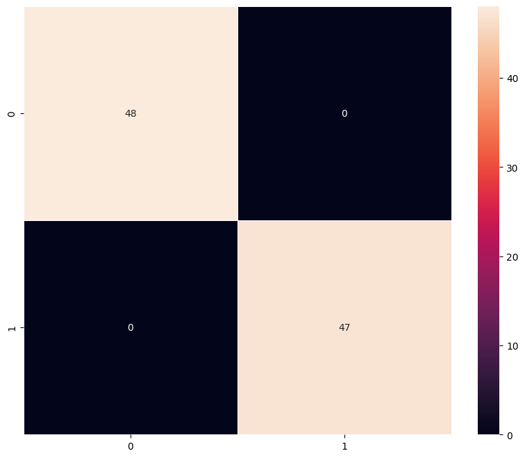

```python
print("Final Model (3) - Test Set Performance")
cnn_model_3_test_perf = model_performance_classification(cnn_model_3, X_test_vgg, pd.Series(y_test))
display(cnn_model_3_test_perf)

print("\n" + "=" * 60)
print("TEST CONFUSION MATRIX")
print("=" * 60 + "\n")

plot_confusion_matrix(cnn_model_3, X_test_vgg, pd.Series(y_test))
```

** OBSERVATION: **

- From the above confusion matrix, we can see the model predicted both classes perfectly for those images with a helmet and without.

** Interpret the result **

From the above confusion matrix, we can see the model predicted both classes perfectly for those images with a helmet and without.

** Perform the Error Analysis **

```python
# For grayscale input model
y_pred_probs = cnn_model_1.predict(X_val)
y_pred_labels = (y_pred_probs > 0.5).astype(int).reshape(-1)

# If your model uses RGB (e.g., VGG16-based)
# y_pred_probs = cnn_model_2.predict(X_val_vgg)
# y_pred_labels = (y_pred_probs > 0.5).astype(int).reshape(-1)
```

```
3/3 ━━━━━━━━━━━━━━━━━━━━ 0s 17ms/step
```

```python
# Get true labels
y_true = y_val if isinstance(y_val, np.ndarray) else y_val.to_numpy()

# Find misclassified indexes
misclassified_idxs = np.where(y_pred_labels != y_true)[0]
print(f"Total misclassifications: {len(misclassified_idxs)}")
```

```
Total misclassifications: 2
```

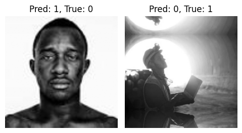

```python
# Show a few misclassified images
plt.figure(figsize=(12, 6))
for i, idx in enumerate(misclassified_idxs[:5]):
    plt.subplot(1, 5, i+1)
    image = X_val[idx].reshape(X_val.shape[1], X_val.shape[2])
    plt.imshow(image, cmap='gray')
    plt.title(f"Pred: {y_pred_labels[idx]}, True: {y_true[idx]}")
    plt.axis('off')
plt.tight_layout()
plt.show()
```

** OBSERVATION:**

```python
print("Classification Report:")
print(classification_report(y_true, y_pred_labels, target_names=["No Helmet", "Helmet"]))

print("\nConfusion Matrix:")
print(confusion_matrix(y_true, y_pred_labels))
```

```
Classification Report:
              precision    recall  f1-score   support

   No Helmet       0.98      0.98      0.98        48
      Helmet       0.98      0.98      0.98        47

    accuracy                           0.98        95
   macro avg       0.98      0.98      0.98        95
weighted avg       0.98      0.98      0.98        95


Confusion Matrix:
[[47  1]
 [ 1 46]]
```

```python
error_data = pd.DataFrame({
    "Index": misclassified_idxs,
    "Predicted": y_pred_labels[misclassified_idxs],
    "Actual": y_true[misclassified_idxs],
    "Confidence": y_pred_probs[misclassified_idxs].reshape(-1)
})

display(error_data.head())
```

|  | Index | Predicted | Actual | Confidence |
| --- | --- | --- | --- | --- |
| 0 | 10 | 1 | 0 | 0.99311 |
| 1 | 55 | 0 | 1 | 0.05096 |

# **Actionable Insights & Recommendations**

**Business Recommendations:**

1. The model is ready for limited deployment and pilot testing.
- With 100% test set performance. The model is suitable for rollout in controlled environments (e.g., construction sites with mounted cameras). Begin pilot deployments to test real-world generalization and edge cases.
2. Create an automated alert pipeline.
- Integrate the model into an edge or cloud-based monitoring solution that triggers alerts when workers are detected without helmets, improving real-time safety compliance.
3. Invest in additional labeled data to improve robustness.
- Even though current performance is excellent, expanding the dataset with more diverse examples (e.g., blurry images, occlusions, different lighting) would further strengthen generalization before full production deployment.
4. Evaluate model bias and failure cases in real-world usage
- Monitor false positives and false negatives carefully once deployed. For example, verify that the model doesn’t confuse hard hats with other headwear or misclassify based on skin tone or clothing color.

Power Ahead!